# Machine Learning: Human Activity Recognition

Paul M. Washburn

September 2015

# Overview

### Introduction

This is an assignment in the course Practical Machine Learning, which is course number 8 of 10 in Johns Hopkins Data Science Specialization.

The [Human Activity Recognition](http://groupware.les.inf.puc-rio.br/har) (HAR) dataset is a large compilation of metrics describing the movement patterns of certain individuals.

### Background

Read More at: http://groupware.les.inf.puc-rio.br/har#ixzz3pVa0EBDJ

Using devices such as Jawbone Up, Nike FuelBand, and Fitbit it is now possible to collect a large amount of data about personal activity relatively inexpensively. These type of devices are part of the quantified self movement - a group of enthusiasts who take measurements about themselves regularly to improve their health, to find patterns in their behavior, or because they are tech geeks. One thing that people regularly do is quantify how much of a particular activity they do, but they rarely quantify how well they do it. In this project, your goal will be to use data from accelerometers on the belt, forearm, arm, and dumbell of 6 participants. They were asked to perform barbell lifts correctly and incorrectly in 5 different ways. More information is available from the website here: http://groupware.les.inf.puc-rio.br/har (see the section on the Weight Lifting Exercise Dataset).

### Objectives:

- Predict the manner in which exercises were performed (‘classe’)
  - May use any variable to predict with
- Create a report on how model was built
  - How cross-validation was used
  - What your expectations were for out of sample error
  - Justify the choices made
- Submit GitHub repo with R Markdown compiled for HTML
  - Text should be less than 2000 words
  - Figures <= 5
- Apply your machine learning algorithm to the 20 test cases available in the test data
  - Submit predictions in appropriate format; see the programming assignment for how to submit for automated grading

### Data Overview

# Data Acquisition, Exploration and Feature Reduction

Load the libraries necessary and set the seed for reproducibility.

```r
set.seed(8008135)
library(caret)
```

```r
library(corrplot)
```

Download the [training](https://d396qusza40orc.cloudfront.net/predmachlearn/pml-training.csv) and [testing](https://d396qusza40orc.cloudfront.net/predmachlearn/pml-testing.csv) datasets from their source and load into R.

```r
setwd("C:/Users/Paul/Desktop/R")
path <- "https://d396qusza40orc.cloudfront.net/predmachlearn/pml-training.csv"
#download.file(path, destfile="training.csv")
path <- "https://d396qusza40orc.cloudfront.net/predmachlearn/pml-testing.csv"
#download.file(path, destfile="testing.csv")
trainingRaw <- read.csv("training.csv", header=TRUE,
                     na.strings=c("", "NA", "NULL", "#DIV/0!"))
testingRaw <- read.csv("testing.csv", header=TRUE,
                     na.strings=c("", "NA", "NULL", "#DIV/0!"))
```

Get to know the training dataset.

```r
dim(trainingRaw)
```

```
## [1] 19622   160
```

```r
dim(testingRaw)
```

```
## [1]  20 160
```

The training dataset contains 19622 observations of 160 variables. Many of the variables have NA values, which we will exclude below.

```r
rmNaColumn <- function (x) {
  !any(is.na(x) | x=="")
  }
clean <- trainingRaw[sapply(trainingRaw, rmNaColumn)]
cleanTestingForLater <- testingRaw[sapply(testingRaw, rmNaColumn)]
dim(clean)
```

```
## [1] 19622    60
```

```r
dim(cleanTestingForLater)
```

```
## [1] 20 60
```

The updated dataset has fewer variables than before since several columns were completely NA. Now partition the data set into training and test sets. Recall that classe is the outcome variable we are trying to predict.

```r
inTrain <- createDataPartition(clean$classe, p=0.7, list=FALSE)
cleanTraining <- clean[inTrain,]
cleanTesting <- clean[-inTrain,]
dim(cleanTraining)
```

```
## [1] 13737    60
```

```r
dim(cleanTesting)
```

```
## [1] 5885   60
```

Delete more unnecessary columns.

```r
forDelete <- grepl("X|user_name|timestamp|new_window", colnames(cleanTraining))
cleanTraining <- cleanTraining[, !forDelete]
cleanTesting <- cleanTesting[, !forDelete]
cleanTestingForLater <- cleanTestingForLater[, !forDelete]
dim(cleanTraining)
```

```
## [1] 13737    54
```

```r
dim(cleanTesting)
```

```
## [1] 5885   54
```

```r
dim(cleanTestingForLater)
```

```
## [1] 20 54
```

Since there are 53 variables let’s visualize the the dataset using a dendrogram. This highlights the fact that there is a lot going on in this dataset, meaning we might be fitting the model to variables that don’t matter at a great cost to computational efficiency.

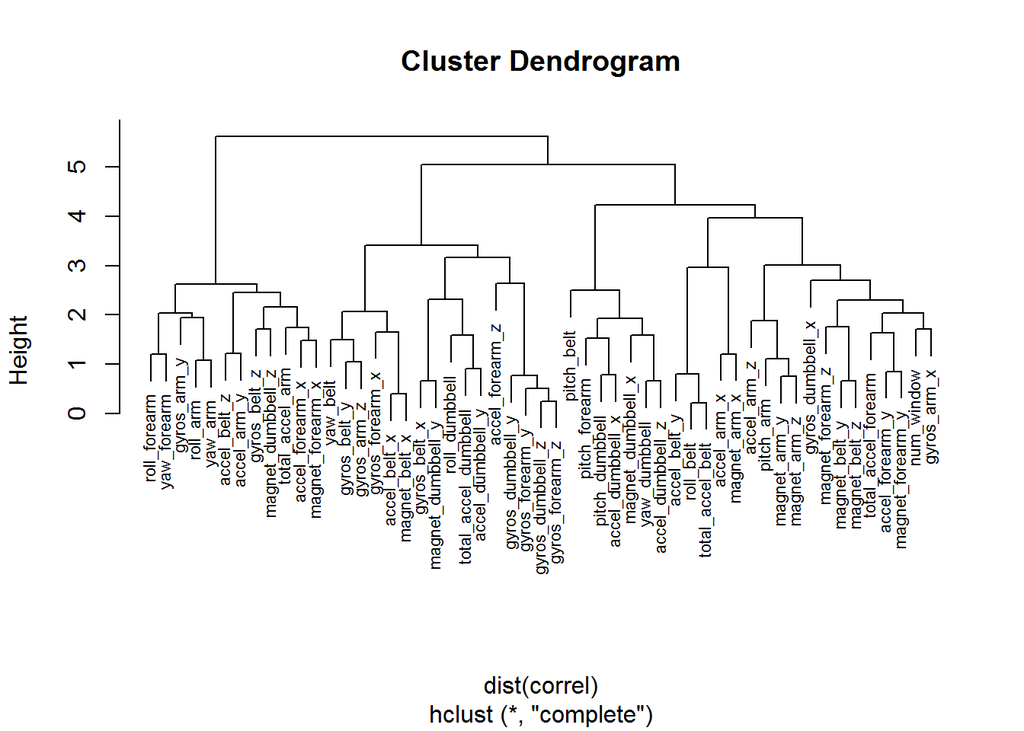

```r
correl <- cor(cleanTraining[, -54])
plot(hclust(dist(correl)), cex = 0.7)
```